# Codebook for Replication study of Kerwer et al.(2020)

### OSA

#### Distribution

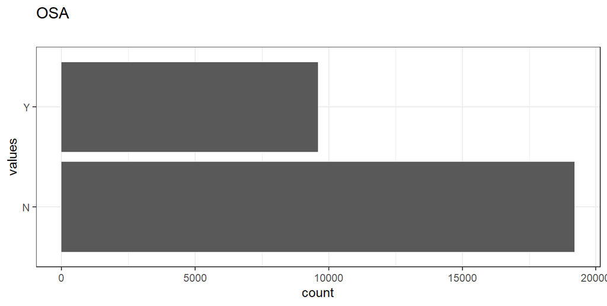

Distribution of values for OSA

0 missing values.

#### Summary statistics

| name | data_type | n_missing | complete_rate | n_unique | empty | min | max | whitespace | label |
| --- | --- | --- | --- | --- | --- | --- | --- | --- | --- |
| OSA | character | 0 | 1 | 2 | 0 | 1 | 1 | 0 | NA |

### text_order

#### Distribution

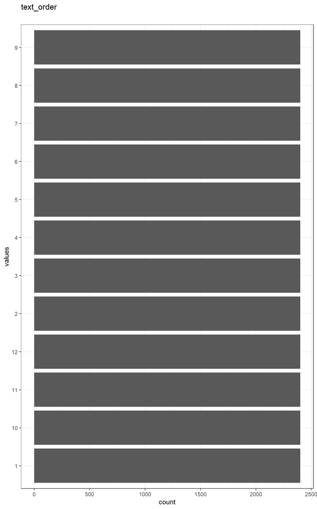

Distribution of values for text_order

0 missing values.

#### Summary statistics

| name | data_type | n_missing | complete_rate | n_unique | empty | min | max | whitespace | label |
| --- | --- | --- | --- | --- | --- | --- | --- | --- | --- |
| text_order | character | 0 | 1 | 12 | 0 | 1 | 2 | 0 | NA |

## Missingness report

## codebook: Exit

```r
codebook(df_Exit,metadata_table = FALSE, metadata_json = FALSE)
```

### Metadata

#### Description

**Dataset name**: df_Exit

The dataset has N=150 rows and 24 columns. 79 rows have no missing values on any column.

**Metadata for search engines**

- **Date published**: 2022-04-19

| x |
| --- |
| CB |
| CRid01 |
| CRid02 |
| CRid03 |
| CRid04 |
| CRid05 |
| CRid06 |
| Content |
| NH |
| OSA |
| Q_presented |
| Q_type |
| Qid01 |
| Qid02 |
| Qid03 |
| Question |
| Set_id |
| Test_id |
| Topic |
| correct_response |
| identifier |
| jatosStudyResultId |
| response |
| text_order |

#Variables

### CB

#### Distribution

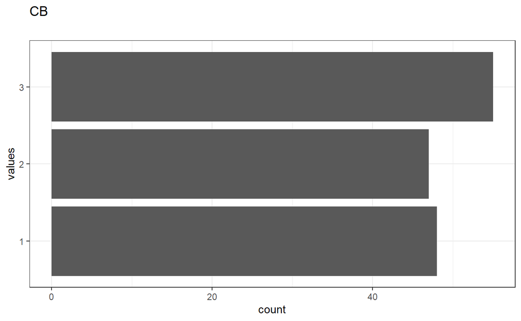

Distribution of values for CB

0 missing values.

#### Summary statistics

| name | data_type | n_missing | complete_rate | n_unique | empty | min | max | whitespace | label |
| --- | --- | --- | --- | --- | --- | --- | --- | --- | --- |
| CB | character | 0 | 1 | 3 | 0 | 1 | 1 | 0 | NA |

### CRid01

#### Distribution

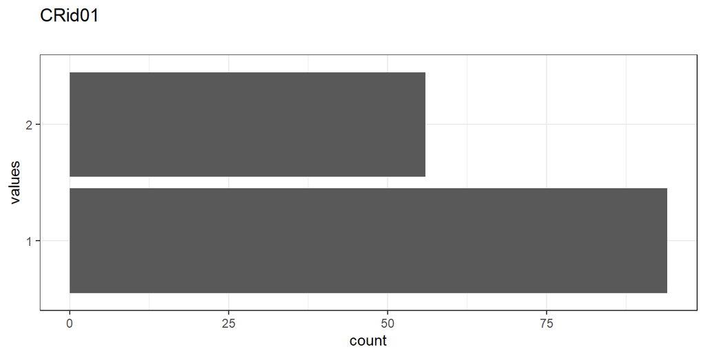

Distribution of values for CRid01

0 missing values.

#### Summary statistics

| name | data_type | n_missing | complete_rate | n_unique | empty | min | max | whitespace | label |
| --- | --- | --- | --- | --- | --- | --- | --- | --- | --- |
| CRid01 | character | 0 | 1 | 2 | 0 | 1 | 1 | 0 | NA |

### CRid02

#### Distribution

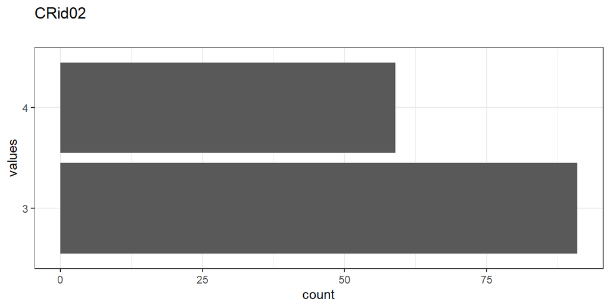

Distribution of values for CRid02

0 missing values.

#### Summary statistics

| name | data_type | n_missing | complete_rate | n_unique | empty | min | max | whitespace | label |
| --- | --- | --- | --- | --- | --- | --- | --- | --- | --- |
| CRid02 | character | 0 | 1 | 2 | 0 | 1 | 1 | 0 | NA |

### CRid03

#### Distribution

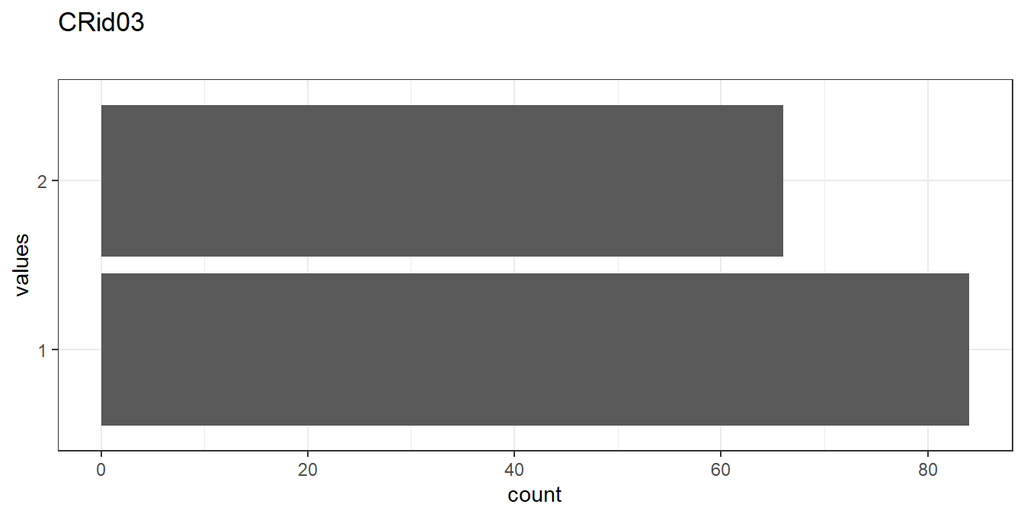

Distribution of values for CRid03

0 missing values.

#### Summary statistics

| name | data_type | n_missing | complete_rate | n_unique | empty | min | max | whitespace | label |
| --- | --- | --- | --- | --- | --- | --- | --- | --- | --- |
| CRid03 | character | 0 | 1 | 2 | 0 | 1 | 1 | 0 | NA |

### CRid04

#### Distribution

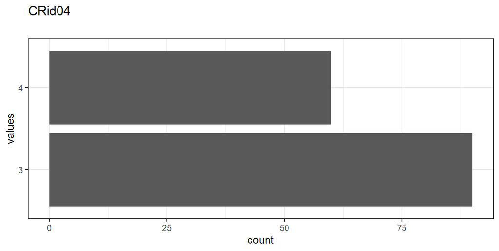

Distribution of values for CRid04

0 missing values.

#### Summary statistics

| name | data_type | n_missing | complete_rate | n_unique | empty | min | max | whitespace | label |
| --- | --- | --- | --- | --- | --- | --- | --- | --- | --- |
| CRid04 | character | 0 | 1 | 2 | 0 | 1 | 1 | 0 | NA |

### CRid05

#### Distribution

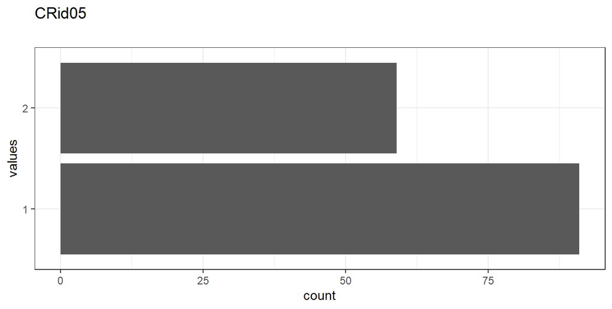

Distribution of values for CRid05

0 missing values.

#### Summary statistics

| name | data_type | n_missing | complete_rate | n_unique | empty | min | max | whitespace | label |
| --- | --- | --- | --- | --- | --- | --- | --- | --- | --- |
| CRid05 | character | 0 | 1 | 2 | 0 | 1 | 1 | 0 | NA |

### CRid06

#### Distribution

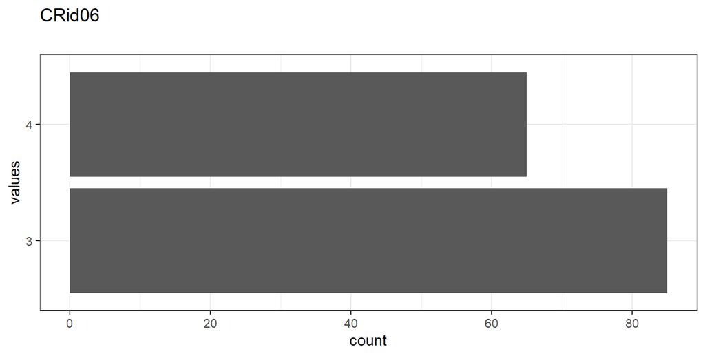

Distribution of values for CRid06

0 missing values.

#### Summary statistics

| name | data_type | n_missing | complete_rate | n_unique | empty | min | max | whitespace | label |
| --- | --- | --- | --- | --- | --- | --- | --- | --- | --- |
| CRid06 | character | 0 | 1 | 2 | 0 | 1 | 1 | 0 | NA |

### Content

#### Distribution

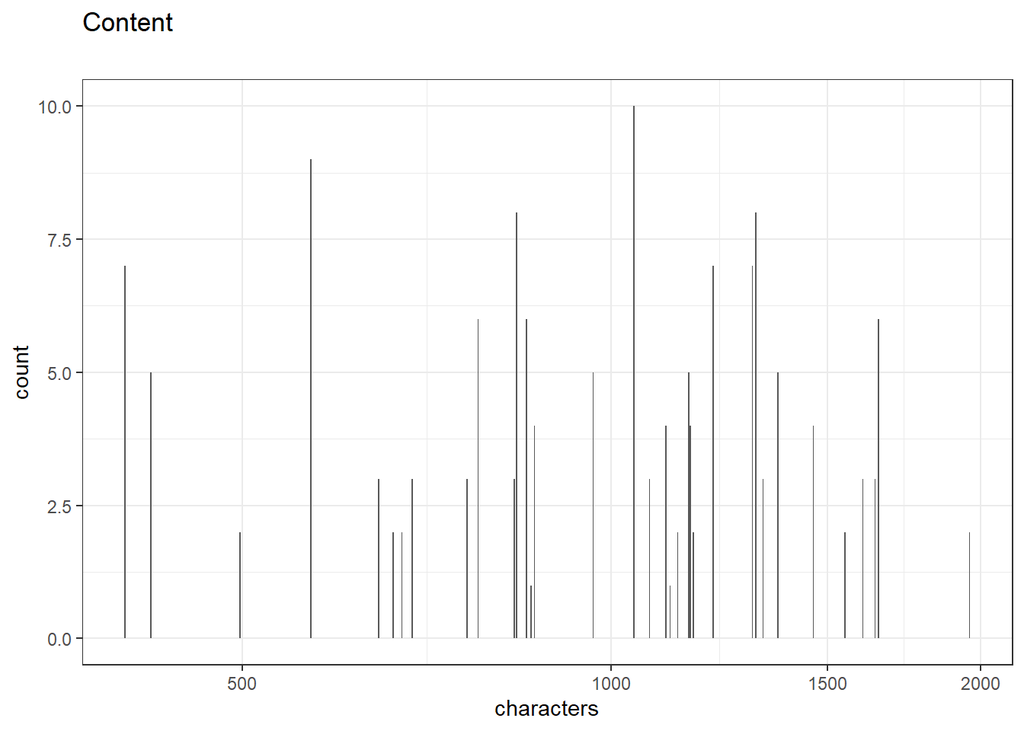

Distribution of values for Content

0 missing values.

#### Summary statistics

| name | data_type | n_missing | complete_rate | n_unique | empty | min | max | whitespace | label |
| --- | --- | --- | --- | --- | --- | --- | --- | --- | --- |
| Content | character | 0 | 1 | 36 | 0 | 401 | 1960 | 0 | NA |

### NH

#### Distribution

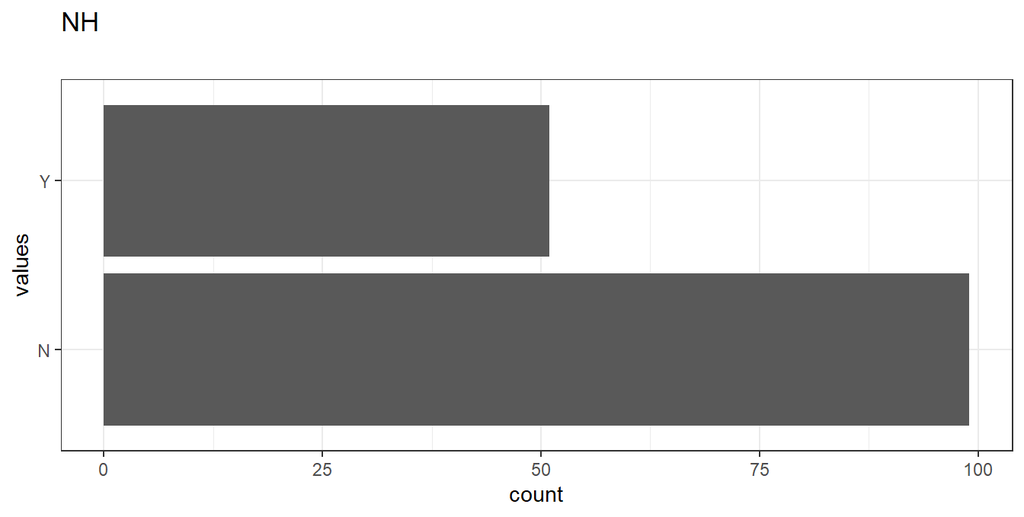

Distribution of values for NH

0 missing values.

#### Summary statistics

| name | data_type | n_missing | complete_rate | n_unique | empty | min | max | whitespace | label |
| --- | --- | --- | --- | --- | --- | --- | --- | --- | --- |
| NH | character | 0 | 1 | 2 | 0 | 1 | 1 | 0 | NA |

### OSA

#### Distribution

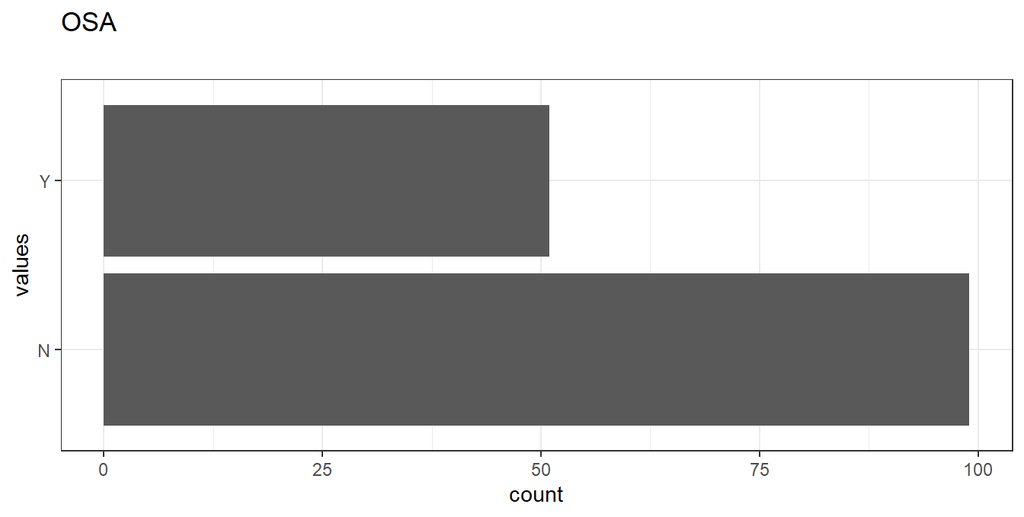

Distribution of values for OSA

0 missing values.

#### Summary statistics

| name | data_type | n_missing | complete_rate | n_unique | empty | min | max | whitespace | label |
| --- | --- | --- | --- | --- | --- | --- | --- | --- | --- |
| OSA | character | 0 | 1 | 2 | 0 | 1 | 1 | 0 | NA |

### Q_presented

#### Distribution

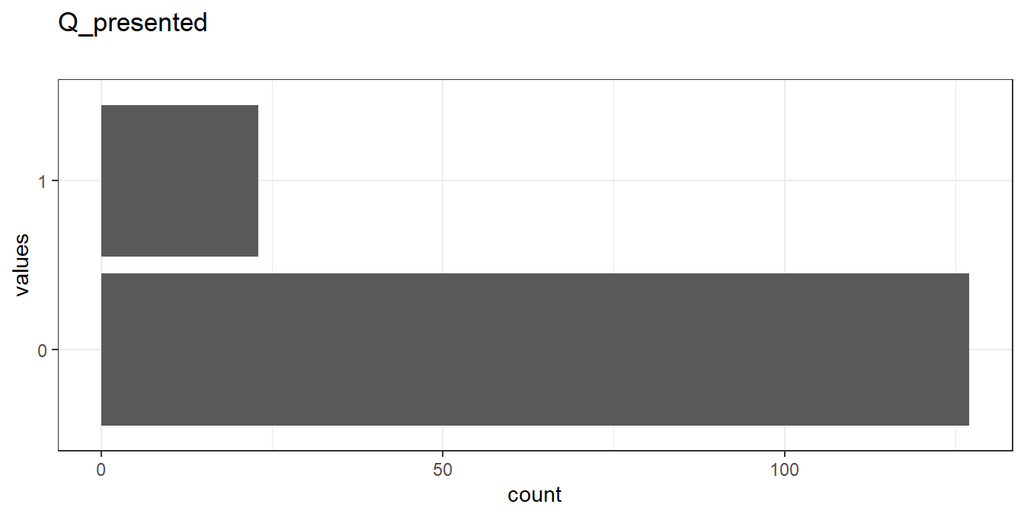

Distribution of values for Q_presented

0 missing values.

#### Summary statistics

| name | data_type | n_missing | complete_rate | n_unique | empty | min | max | whitespace | label |
| --- | --- | --- | --- | --- | --- | --- | --- | --- | --- |
| Q_presented | character | 0 | 1 | 2 | 0 | 1 | 1 | 0 | NA |

### Q_type

#### Distribution

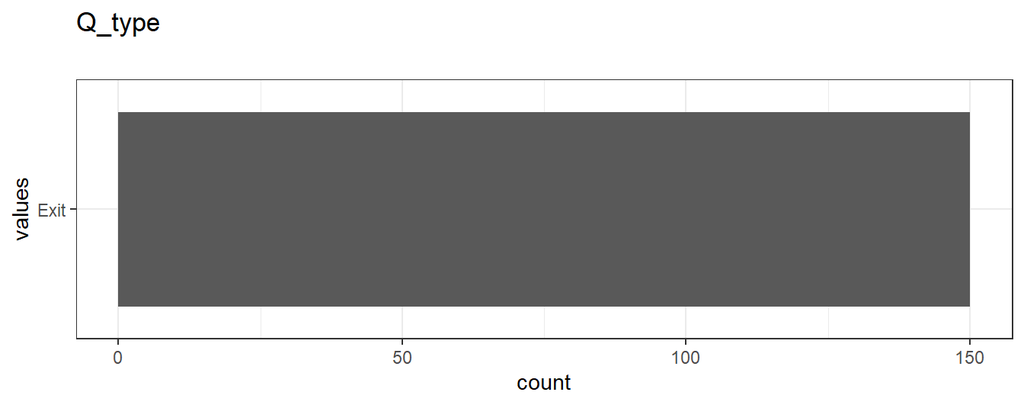

Distribution of values for Q_type

0 missing values.

#### Summary statistics

| name | data_type | n_missing | complete_rate | n_unique | empty | min | max | whitespace | label |
| --- | --- | --- | --- | --- | --- | --- | --- | --- | --- |
| Q_type | character | 0 | 1 | 1 | 0 | 4 | 4 | 0 | NA |

### Qid01

#### Distribution

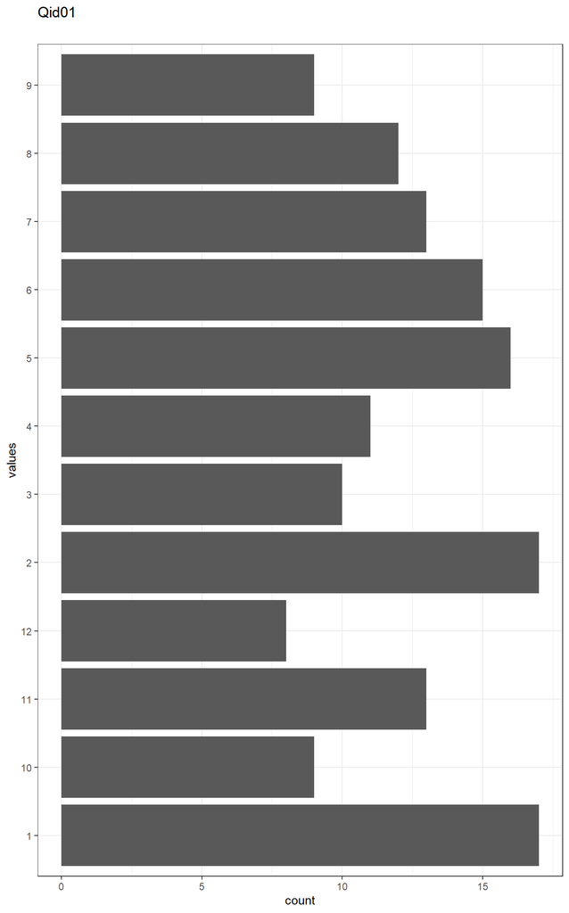

Distribution of values for Qid01

0 missing values.

#### Summary statistics

| name | data_type | n_missing | complete_rate | n_unique | empty | min | max | whitespace | label |
| --- | --- | --- | --- | --- | --- | --- | --- | --- | --- |
| Qid01 | character | 0 | 1 | 12 | 0 | 1 | 2 | 0 | NA |

### Qid02

#### Distribution

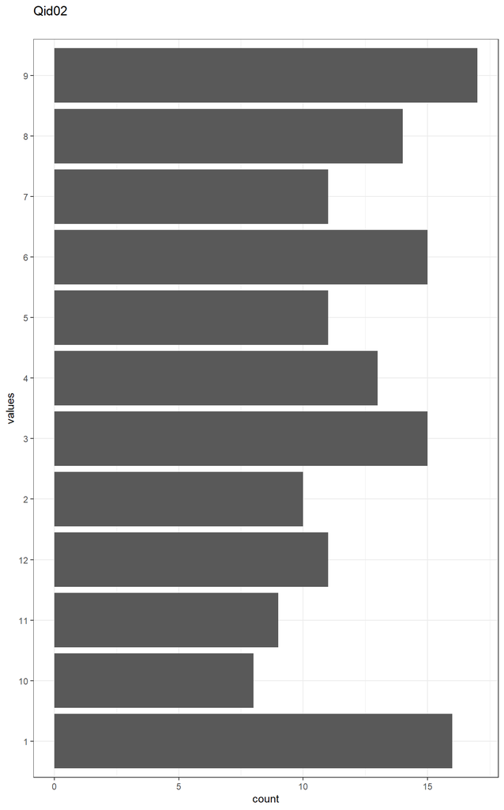

Distribution of values for Qid02

0 missing values.

#### Summary statistics

| name | data_type | n_missing | complete_rate | n_unique | empty | min | max | whitespace | label |
| --- | --- | --- | --- | --- | --- | --- | --- | --- | --- |
| Qid02 | character | 0 | 1 | 12 | 0 | 1 | 2 | 0 | NA |

### Qid03

#### Distribution

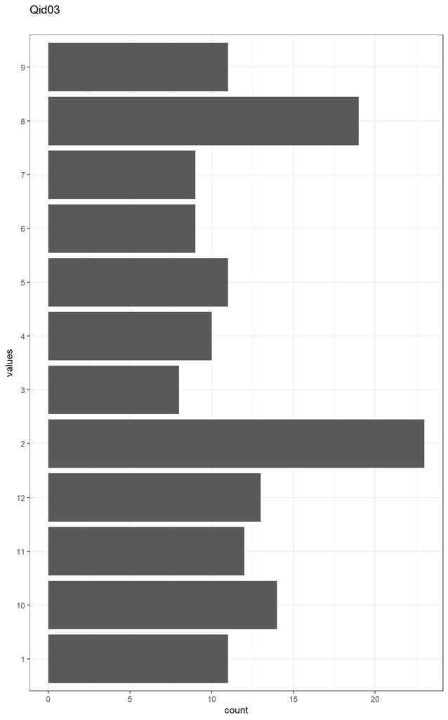

Distribution of values for Qid03

0 missing values.

#### Summary statistics

| name | data_type | n_missing | complete_rate | n_unique | empty | min | max | whitespace | label |
| --- | --- | --- | --- | --- | --- | --- | --- | --- | --- |
| Qid03 | character | 0 | 1 | 12 | 0 | 1 | 2 | 0 | NA |

### Question

#### Distribution

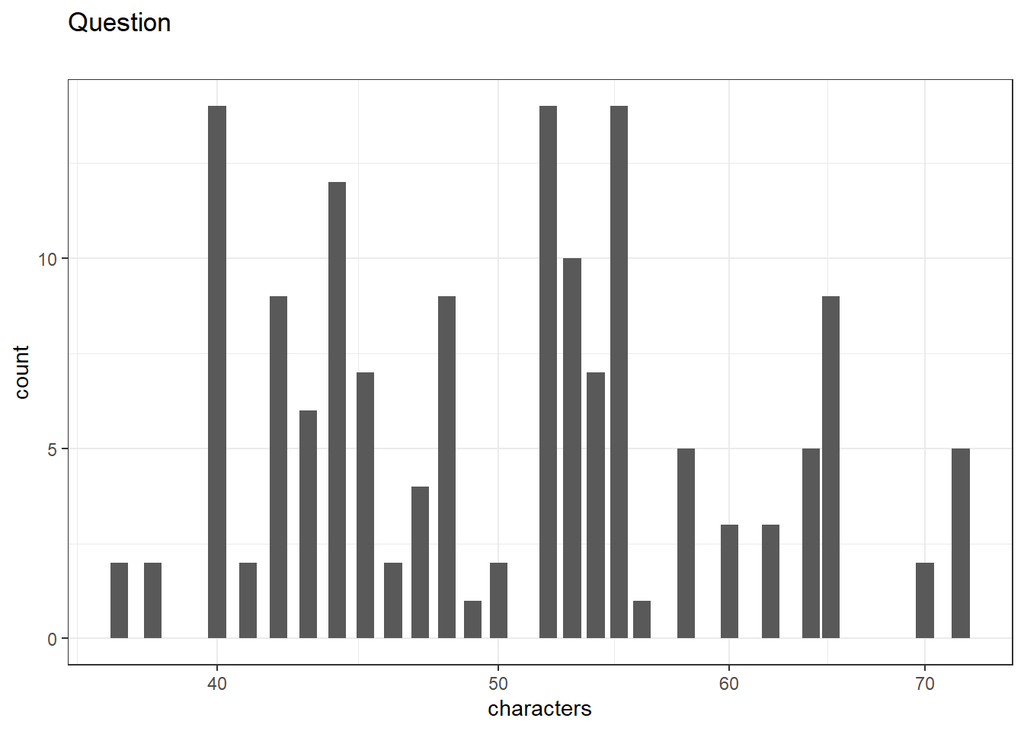

Distribution of values for Question

0 missing values.

#### Summary statistics

| name | data_type | n_missing | complete_rate | n_unique | empty | min | max | whitespace | label |
| --- | --- | --- | --- | --- | --- | --- | --- | --- | --- |
| Question | character | 0 | 1 | 46 | 0 | 37 | 72 | 0 | NA |

### Set_id

#### Distribution

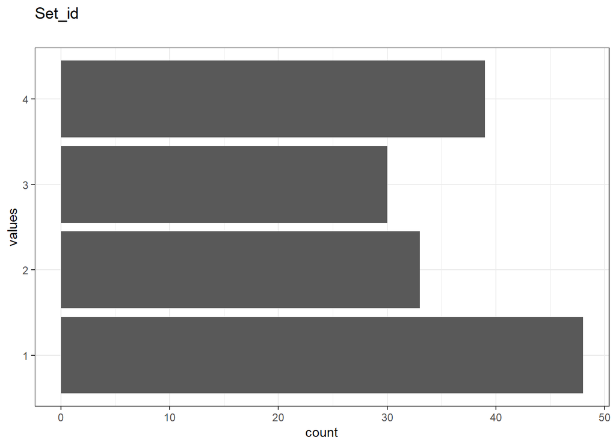

Distribution of values for Set_id

0 missing values.

#### Summary statistics

| name | data_type | n_missing | complete_rate | n_unique | empty | min | max | whitespace | label |
| --- | --- | --- | --- | --- | --- | --- | --- | --- | --- |
| Set_id | character | 0 | 1 | 4 | 0 | 1 | 1 | 0 | NA |

### Test_id

#### Distribution

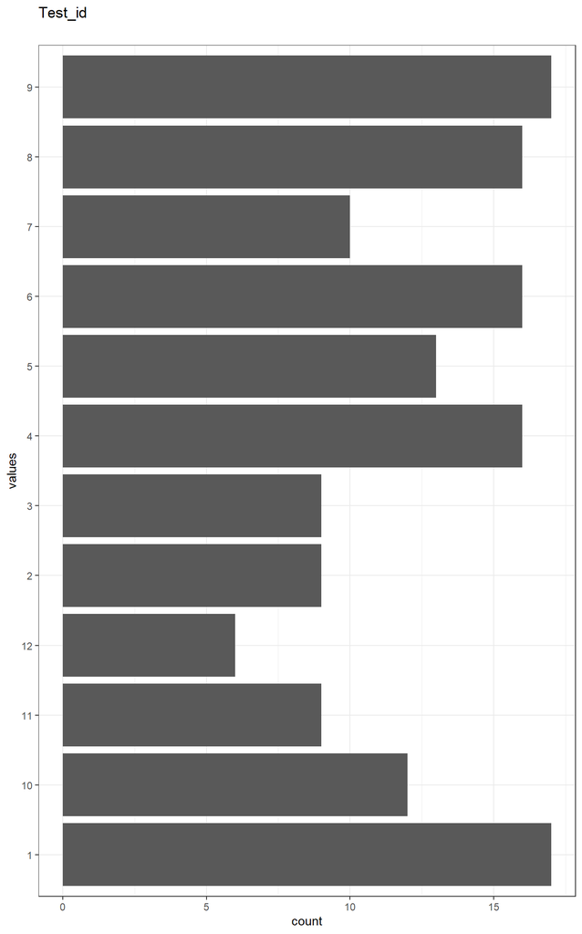

Distribution of values for Test_id

0 missing values.

#### Summary statistics

| name | data_type | n_missing | complete_rate | n_unique | empty | min | max | whitespace | label |
| --- | --- | --- | --- | --- | --- | --- | --- | --- | --- |
| Test_id | character | 0 | 1 | 12 | 0 | 1 | 2 | 0 | NA |

### Topic

#### Distribution

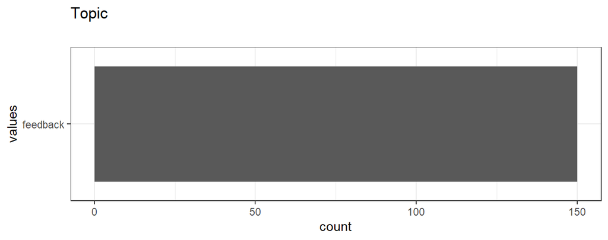

Distribution of values for Topic

0 missing values.

#### Summary statistics

| name | data_type | n_missing | complete_rate | n_unique | empty | min | max | whitespace | label |
| --- | --- | --- | --- | --- | --- | --- | --- | --- | --- |
| Topic | character | 0 | 1 | 1 | 0 | 8 | 8 | 0 | NA |

### correct_response

#### Distribution

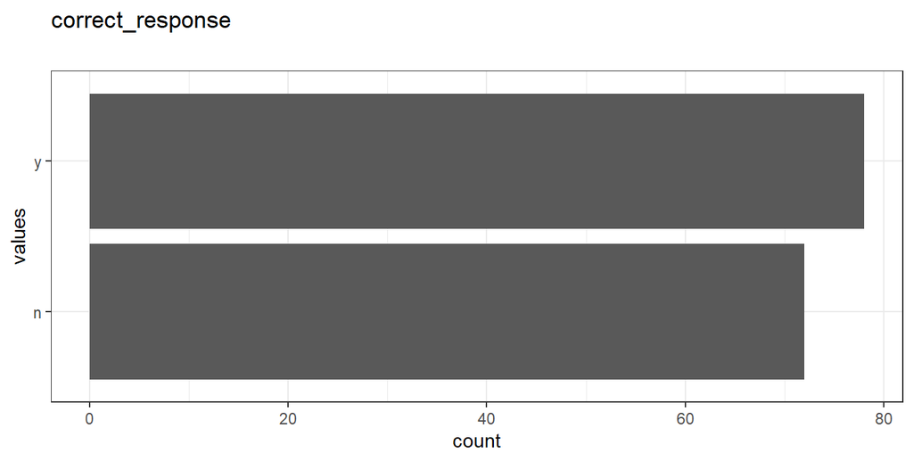

Distribution of values for correct_response

0 missing values.

#### Summary statistics

| name | data_type | n_missing | complete_rate | n_unique | empty | min | max | whitespace | label |
| --- | --- | --- | --- | --- | --- | --- | --- | --- | --- |
| correct_response | character | 0 | 1 | 2 | 0 | 1 | 1 | 0 | NA |

### identifier

#### Distribution

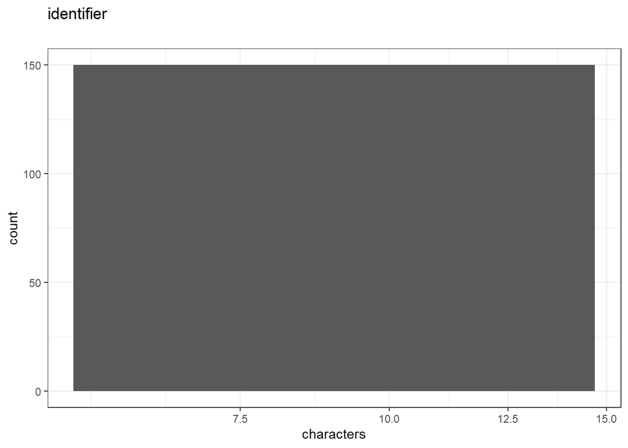

Distribution of values for identifier

0 missing values.

#### Summary statistics

| name | data_type | n_missing | complete_rate | n_unique | empty | min | max | whitespace | label |
| --- | --- | --- | --- | --- | --- | --- | --- | --- | --- |
| identifier | character | 0 | 1 | 150 | 0 | 9 | 9 | 0 | NA |

### jatosStudyResultId

#### Distribution

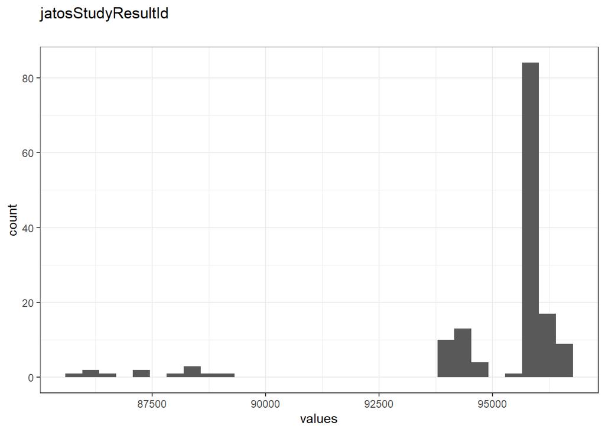

Distribution of values for jatosStudyResultId

0 missing values.

#### Summary statistics

| name | data_type | n_missing | complete_rate | min | median | max | mean | sd | hist | label |
| --- | --- | --- | --- | --- | --- | --- | --- | --- | --- | --- |
| jatosStudyResultId | numeric | 0 | 1 | 85756 | 95744 | 96571 | 94925.99 | 2316.165 | ▁▁▁▂▇ | NA |

### response

#### Distribution

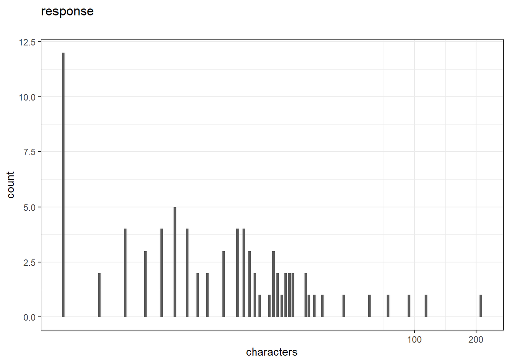

Distribution of values for response

71 missing values.

#### Summary statistics

| name | data_type | n_missing | complete_rate | n_unique | empty | min | max | whitespace | label |
| --- | --- | --- | --- | --- | --- | --- | --- | --- | --- |
| response | character | 71 | 0.5266667 | 67 | 0 | 1 | 211 | 0 | NA |

### text_order

#### Distribution

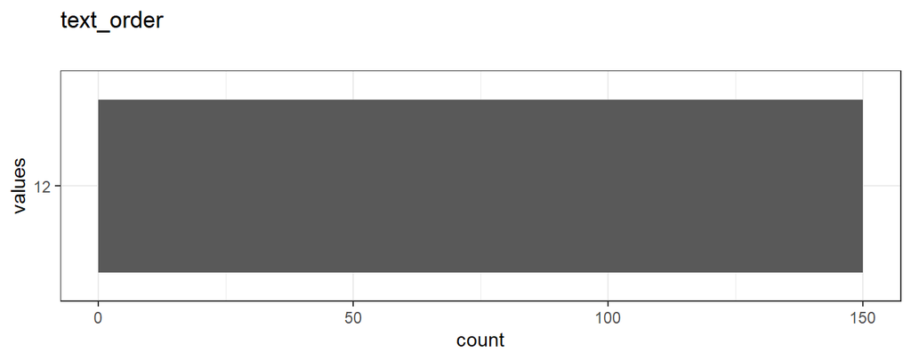

Distribution of values for text_order

0 missing values.

#### Summary statistics

| name | data_type | n_missing | complete_rate | n_unique | empty | min | max | whitespace | label |
| --- | --- | --- | --- | --- | --- | --- | --- | --- | --- |
| text_order | character | 0 | 1 | 1 | 0 | 2 | 2 | 0 | NA |

## Missingness report

| description | response | var_miss | n_miss |
| --- | --- | --- | --- |
| Missing values in 0 variables | 1 | 0 | 79 |
| Missing values in 1 variables | 0 | 1 | 71 |
| Missing values per variable | 71 | 71 | 71 |

## codebook: System info

```r
codebook(df_sys,metadata_table = FALSE, metadata_json = FALSE)
```

### Metadata

#### Description

**Dataset name**: df_sys

The dataset has N=41850 rows and 32 columns. 41850 rows have no missing values on any column.

**Metadata for search engines**

- **Date published**: 2022-04-19

| x |
| --- |
| identifier |
| jatosStudyResultId |
| jatosVersion |
| browser_codename |
| browser_name |
| browser_version |
| count_main |
| date_startdate |
| date_startdateUTC |
| date_starttime |
| experiment_debug |
| experiment_parameters |
| experiment_pilot |
| experiment_taskname |
| experiment_taskversion |
| screen_availableHeight |
| screen_availableWidth |
| screen_colorDepth |
| screen_height |
| screen_pixelDepth |
| screen_screenX |
| screen_screenY |
| screen_width |
| system_os |
| Start Time |
| Last Seen |
| Duration |
| Batch |
| Worker ID |
| Worker Type |
| State |
| Message |

#Variables

### identifier

#### Distribution

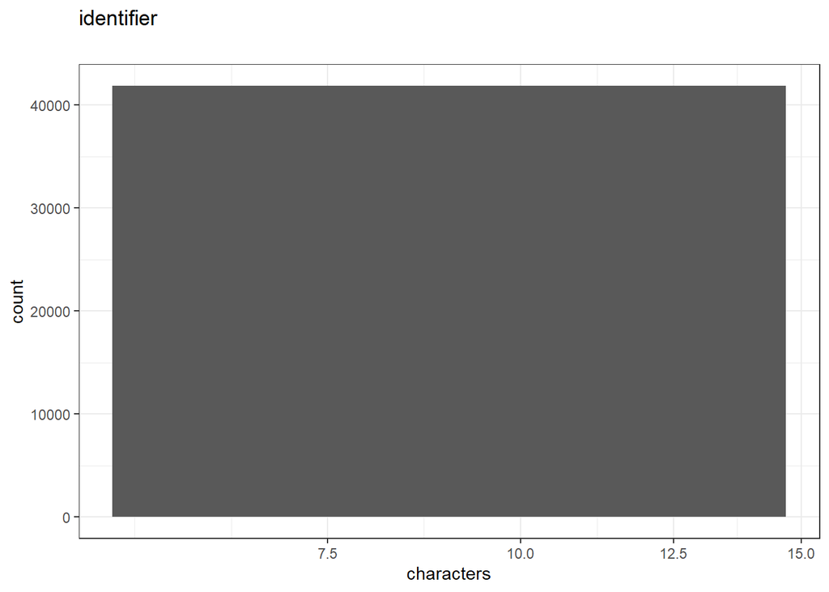

Distribution of values for identifier

0 missing values.

#### Summary statistics

| name | data_type | n_missing | complete_rate | n_unique | empty | min | max | whitespace | label |
| --- | --- | --- | --- | --- | --- | --- | --- | --- | --- |
| identifier | character | 0 | 1 | 150 | 0 | 9 | 9 | 0 | NA |

### jatosStudyResultId

#### Distribution

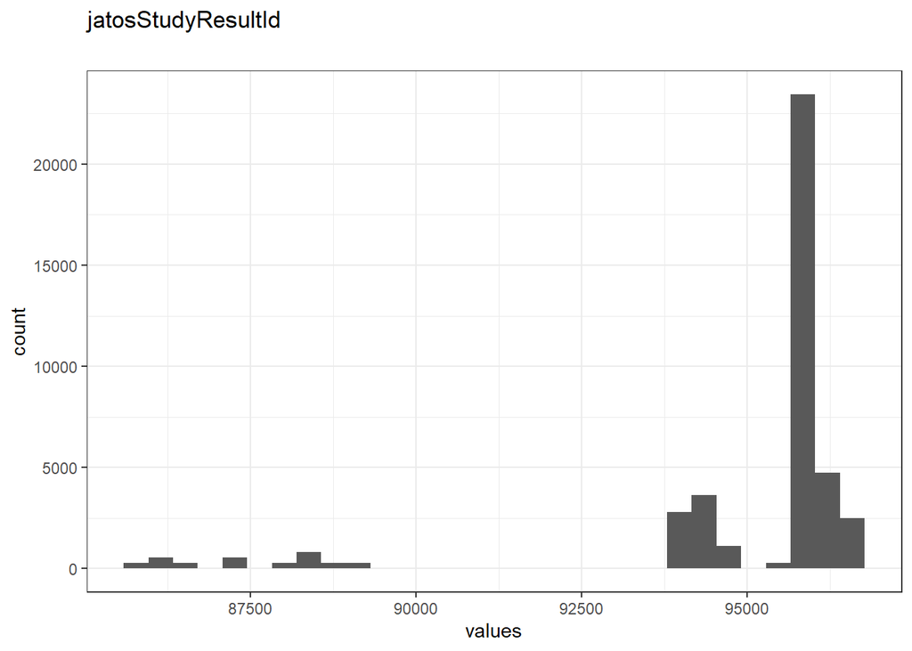

Distribution of values for jatosStudyResultId

0 missing values.

#### Summary statistics

| name | data_type | n_missing | complete_rate | min | median | max | mean | sd | hist | label |
| --- | --- | --- | --- | --- | --- | --- | --- | --- | --- | --- |
| jatosStudyResultId | numeric | 0 | 1 | 85756 | 95744 | 96571 | 94925.99 | 2308.459 | ▁▁▁▂▇ | NA |

### jatosVersion

#### Distribution

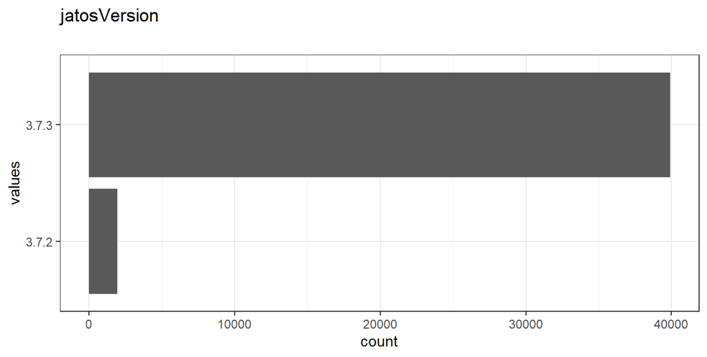

Distribution of values for jatosVersion

0 missing values.

#### Summary statistics

| name | data_type | n_missing | complete_rate | n_unique | empty | min | max | whitespace | label |
| --- | --- | --- | --- | --- | --- | --- | --- | --- | --- |
| jatosVersion | character | 0 | 1 | 2 | 0 | 5 | 5 | 0 | NA |

### browser_codename

#### Distribution

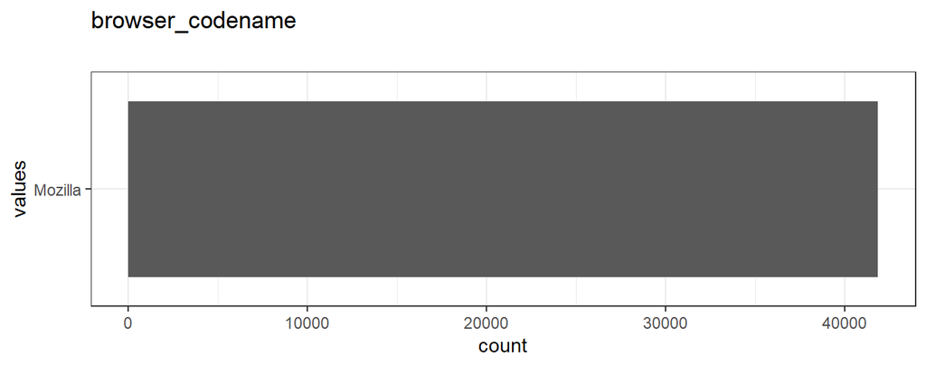

Distribution of values for browser_codename

0 missing values.

#### Summary statistics

| name | data_type | n_missing | complete_rate | n_unique | empty | min | max | whitespace | label |
| --- | --- | --- | --- | --- | --- | --- | --- | --- | --- |
| browser_codename | character | 0 | 1 | 1 | 0 | 7 | 7 | 0 | NA |

### browser_name

#### Distribution

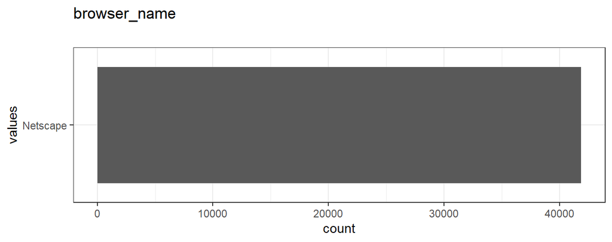

Distribution of values for browser_name

0 missing values.

#### Summary statistics

| name | data_type | n_missing | complete_rate | n_unique | empty | min | max | whitespace | label |
| --- | --- | --- | --- | --- | --- | --- | --- | --- | --- |
| browser_name | character | 0 | 1 | 1 | 0 | 8 | 8 | 0 | NA |

### browser_version

#### Distribution

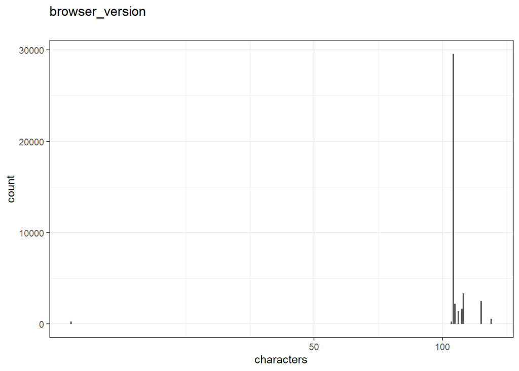

Distribution of values for browser_version

0 missing values.

#### Summary statistics

| name | data_type | n_missing | complete_rate | n_unique | empty | min | max | whitespace | label |
| --- | --- | --- | --- | --- | --- | --- | --- | --- | --- |
| browser_version | character | 0 | 1 | 22 | 0 | 13 | 130 | 0 | NA |

### count_main

#### Distribution

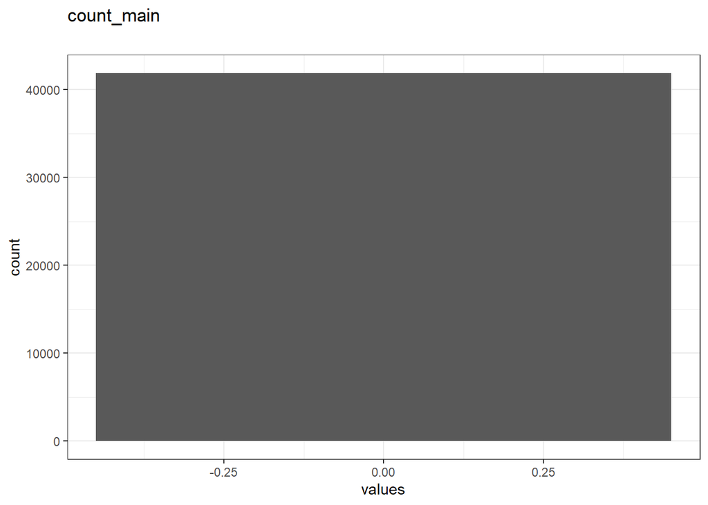

Distribution of values for count_main

0 missing values.

#### Summary statistics

| name | data_type | n_missing | complete_rate | min | median | max | mean | sd | hist | label |
| --- | --- | --- | --- | --- | --- | --- | --- | --- | --- | --- |
| count_main | numeric | 0 | 1 | 0 | 0 | 0 | 0 | 0 | ▁▁▇▁▁ | NA |

### date_startdate

#### Distribution

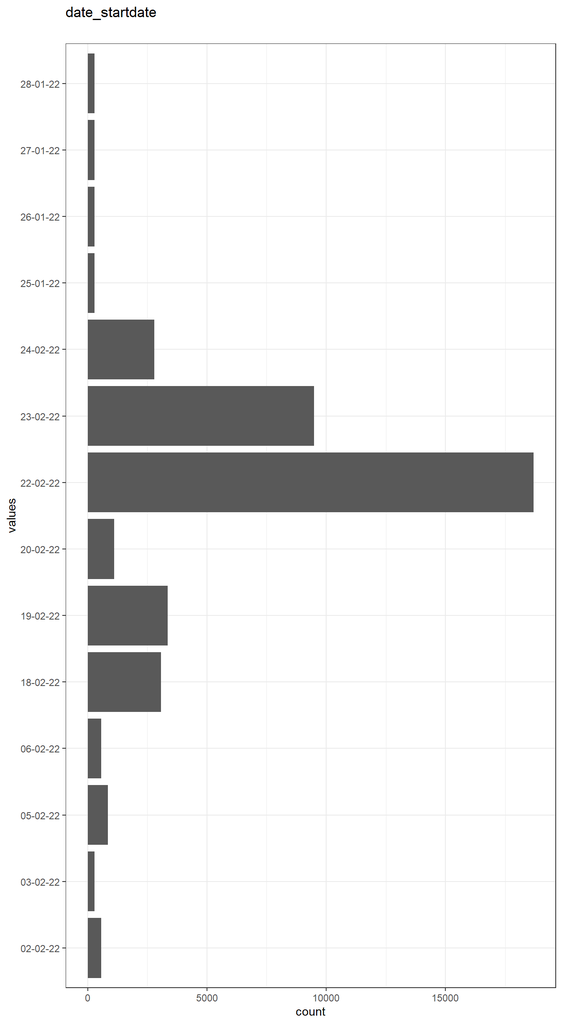

Distribution of values for date_startdate

0 missing values.

#### Summary statistics

| name | data_type | n_missing | complete_rate | n_unique | empty | min | max | whitespace | label |
| --- | --- | --- | --- | --- | --- | --- | --- | --- | --- |
| date_startdate | character | 0 | 1 | 14 | 0 | 8 | 8 | 0 | NA |

### date_startdateUTC

#### Distribution

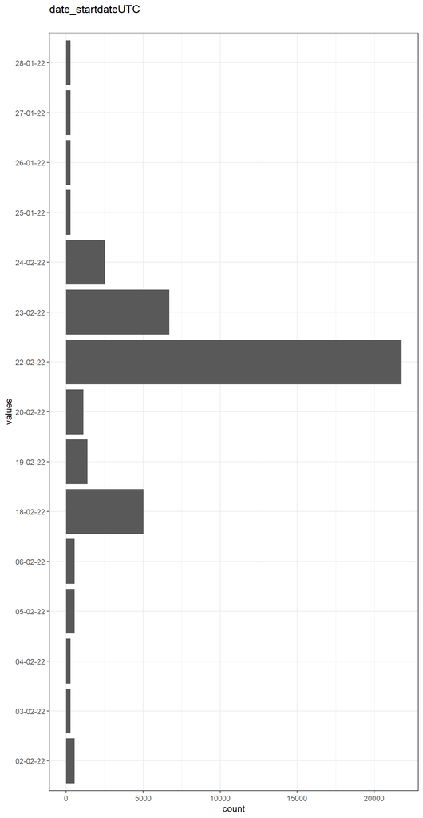

Distribution of values for date_startdateUTC

0 missing values.

#### Summary statistics

| name | data_type | n_missing | complete_rate | n_unique | empty | min | max | whitespace | label |
| --- | --- | --- | --- | --- | --- | --- | --- | --- | --- |
| date_startdateUTC | character | 0 | 1 | 15 | 0 | 8 | 8 | 0 | NA |

### date_starttime

#### Distribution

```
## 149  unique, categorical values, so not shown.
```

0 missing values.

#### Summary statistics

| name | data_type | n_missing | complete_rate | n_unique | min | median | max | units | label |
| --- | --- | --- | --- | --- | --- | --- | --- | --- | --- |
| date_starttime | difftime | 0 | 1 | 149 | 311 | 79044 | 86214 | secs | NA |

### experiment_debug

#### Distribution

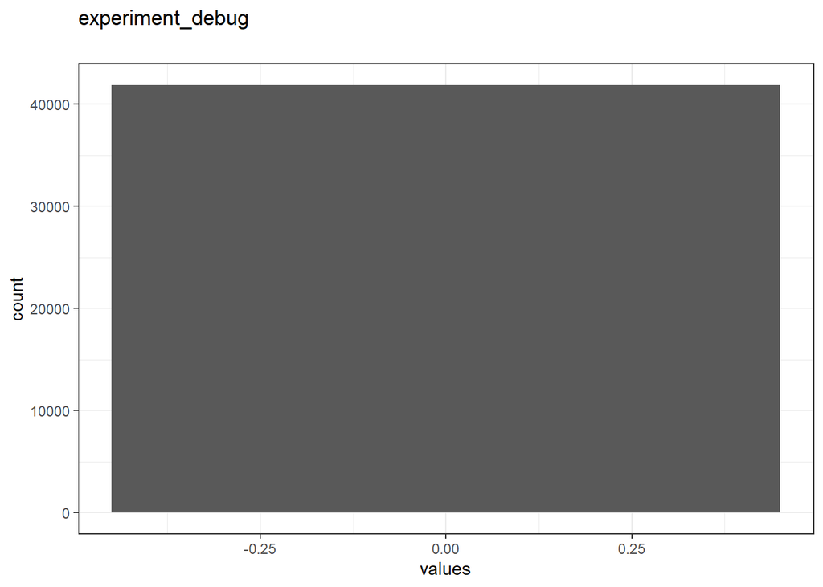

Distribution of values for experiment_debug

0 missing values.

#### Summary statistics

| name | data_type | n_missing | complete_rate | min | median | max | mean | sd | hist | label |
| --- | --- | --- | --- | --- | --- | --- | --- | --- | --- | --- |
| experiment_debug | numeric | 0 | 1 | 0 | 0 | 0 | 0 | 0 | ▁▁▇▁▁ | NA |

### experiment_parameters

#### Distribution

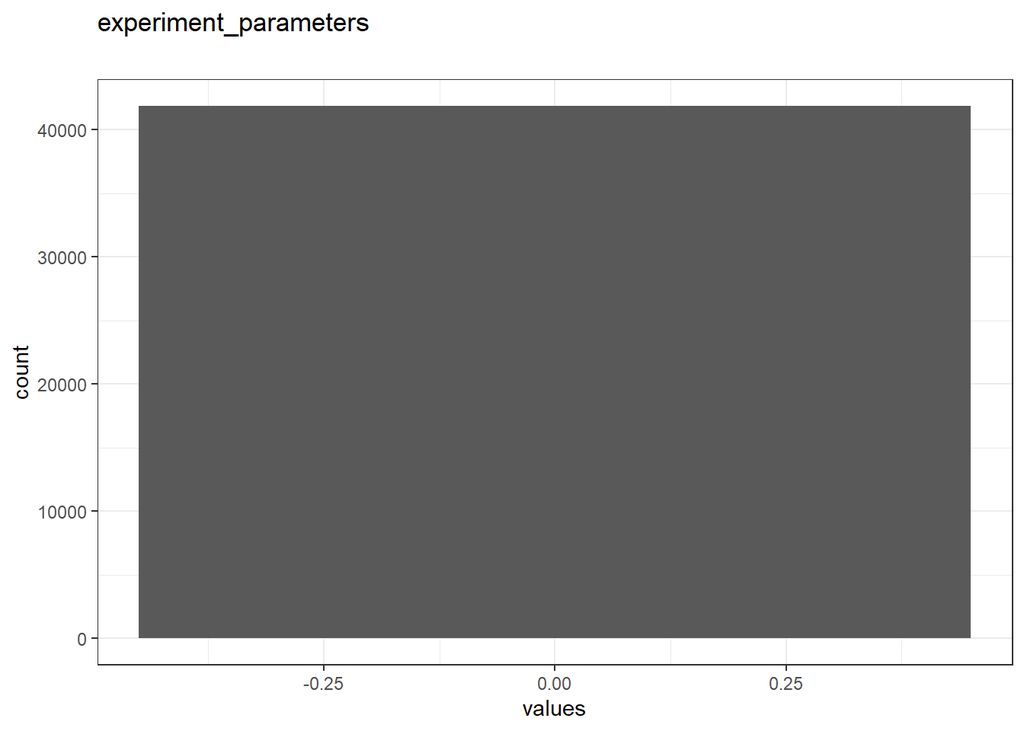

Distribution of values for experiment_parameters

0 missing values.

#### Summary statistics

| name | data_type | n_missing | complete_rate | min | median | max | mean | sd | hist | label |
| --- | --- | --- | --- | --- | --- | --- | --- | --- | --- | --- |
| experiment_parameters | numeric | 0 | 1 | 0 | 0 | 0 | 0 | 0 | ▁▁▇▁▁ | NA |

### experiment_pilot

#### Distribution

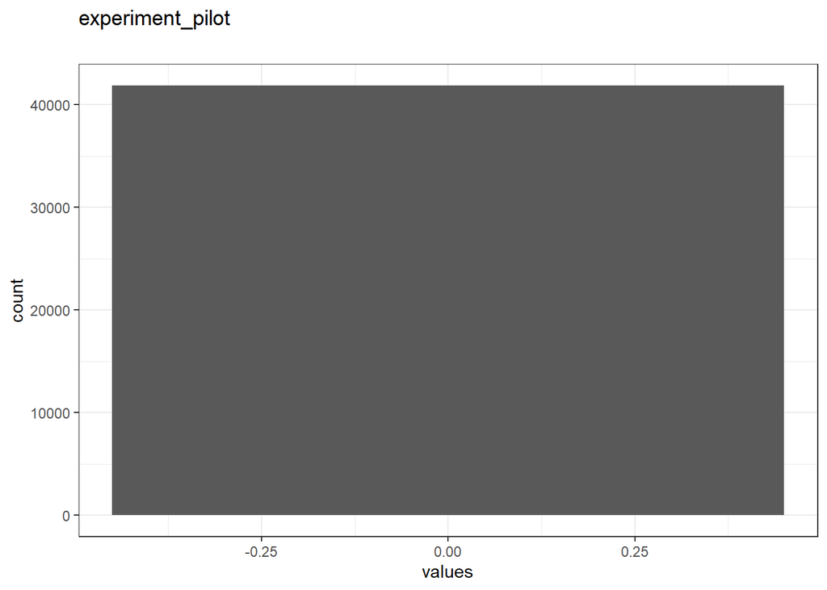

Distribution of values for experiment_pilot

0 missing values.

#### Summary statistics

| name | data_type | n_missing | complete_rate | min | median | max | mean | sd | hist | label |
| --- | --- | --- | --- | --- | --- | --- | --- | --- | --- | --- |
| experiment_pilot | numeric | 0 | 1 | 0 | 0 | 0 | 0 | 0 | ▁▁▇▁▁ | NA |

### experiment_taskname

#### Distribution

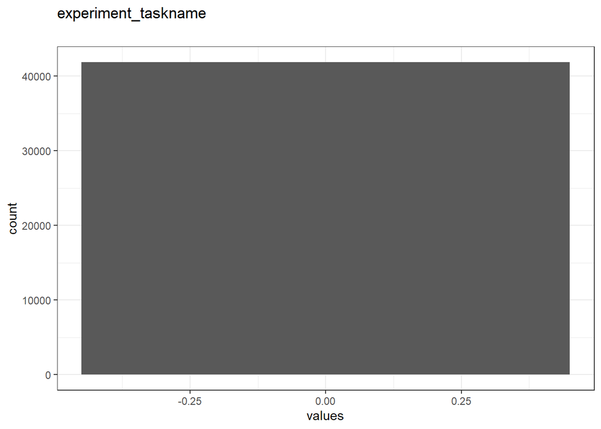

Distribution of values for experiment_taskname

0 missing values.

#### Summary statistics

| name | data_type | n_missing | complete_rate | min | median | max | mean | sd | hist | label |
| --- | --- | --- | --- | --- | --- | --- | --- | --- | --- | --- |
| experiment_taskname | numeric | 0 | 1 | 0 | 0 | 0 | 0 | 0 | ▁▁▇▁▁ | NA |

### experiment_taskversion

#### Distribution

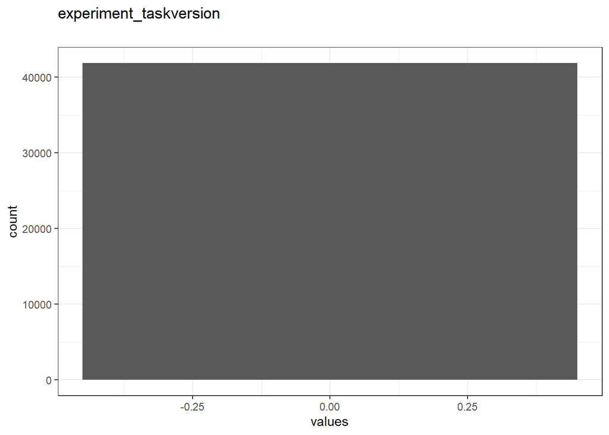

Distribution of values for experiment_taskversion

0 missing values.

#### Summary statistics

| name | data_type | n_missing | complete_rate | min | median | max | mean | sd | hist | label |
| --- | --- | --- | --- | --- | --- | --- | --- | --- | --- | --- |
| experiment_taskversion | numeric | 0 | 1 | 0 | 0 | 0 | 0 | 0 | ▁▁▇▁▁ | NA |

### screen_availableHeight

#### Distribution

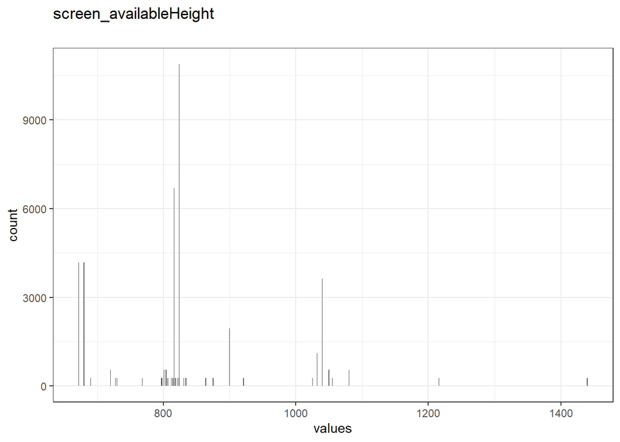

Distribution of values for screen_availableHeight

0 missing values.

#### Summary statistics

| name | data_type | n_missing | complete_rate | min | median | max | mean | sd | hist | label |
| --- | --- | --- | --- | --- | --- | --- | --- | --- | --- | --- |
| screen_availableHeight | numeric | 0 | 1 | 672 | 824 | 1440 | 832.9733 | 126.6496 | ▇▁▂▁▁ | NA |

### screen_availableWidth

#### Distribution

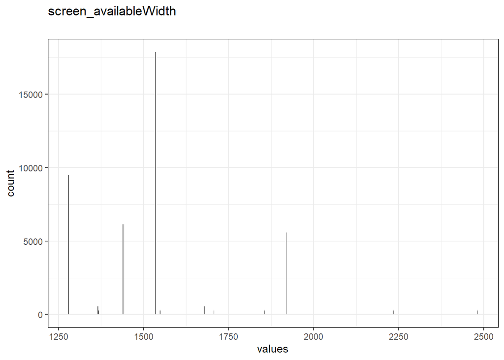

Distribution of values for screen_availableWidth

0 missing values.

#### Summary statistics

| name | data_type | n_missing | complete_rate | min | median | max | mean | sd | hist | label |
| --- | --- | --- | --- | --- | --- | --- | --- | --- | --- | --- |
| screen_availableWidth | numeric | 0 | 1 | 1280 | 1536 | 2482 | 1527.953 | 216.231 | ▇▇▂▁▁ | NA |

### screen_colorDepth

#### Distribution

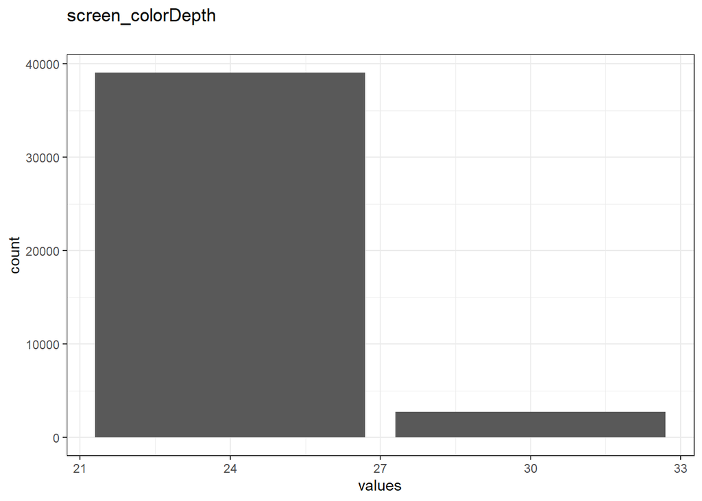

Distribution of values for screen_colorDepth

0 missing values.

#### Summary statistics

| name | data_type | n_missing | complete_rate | min | median | max | mean | sd | hist | label |
| --- | --- | --- | --- | --- | --- | --- | --- | --- | --- | --- |
| screen_colorDepth | numeric | 0 | 1 | 24 | 24 | 30 | 24.4 | 1.496681 | ▇▁▁▁▁ | NA |

### screen_height

#### Distribution

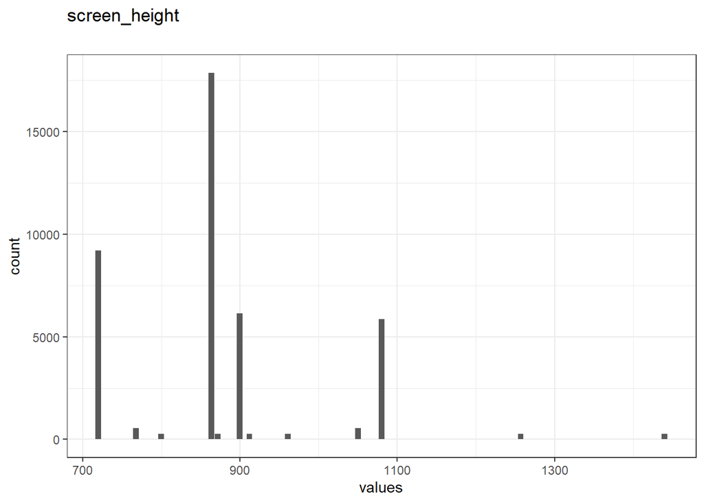

Distribution of values for screen_height

0 missing values.

#### Summary statistics

| name | data_type | n_missing | complete_rate | min | median | max | mean | sd | hist | label |
| --- | --- | --- | --- | --- | --- | --- | --- | --- | --- | --- |
| screen_height | numeric | 0 | 1 | 720 | 864 | 1440 | 876.0933 | 122.7576 | ▇▂▂▁▁ | NA |

### screen_pixelDepth

#### Distribution

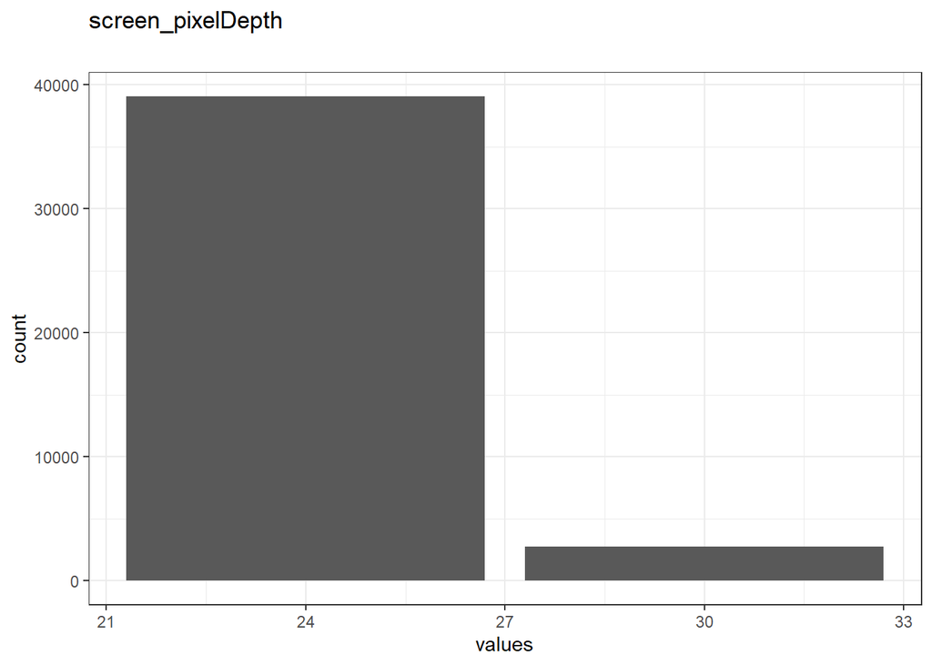

Distribution of values for screen_pixelDepth

0 missing values.

#### Summary statistics

| name | data_type | n_missing | complete_rate | min | median | max | mean | sd | hist | label |
| --- | --- | --- | --- | --- | --- | --- | --- | --- | --- | --- |
| screen_pixelDepth | numeric | 0 | 1 | 24 | 24 | 30 | 24.4 | 1.496681 | ▇▁▁▁▁ | NA |

### screen_screenX

#### Distribution

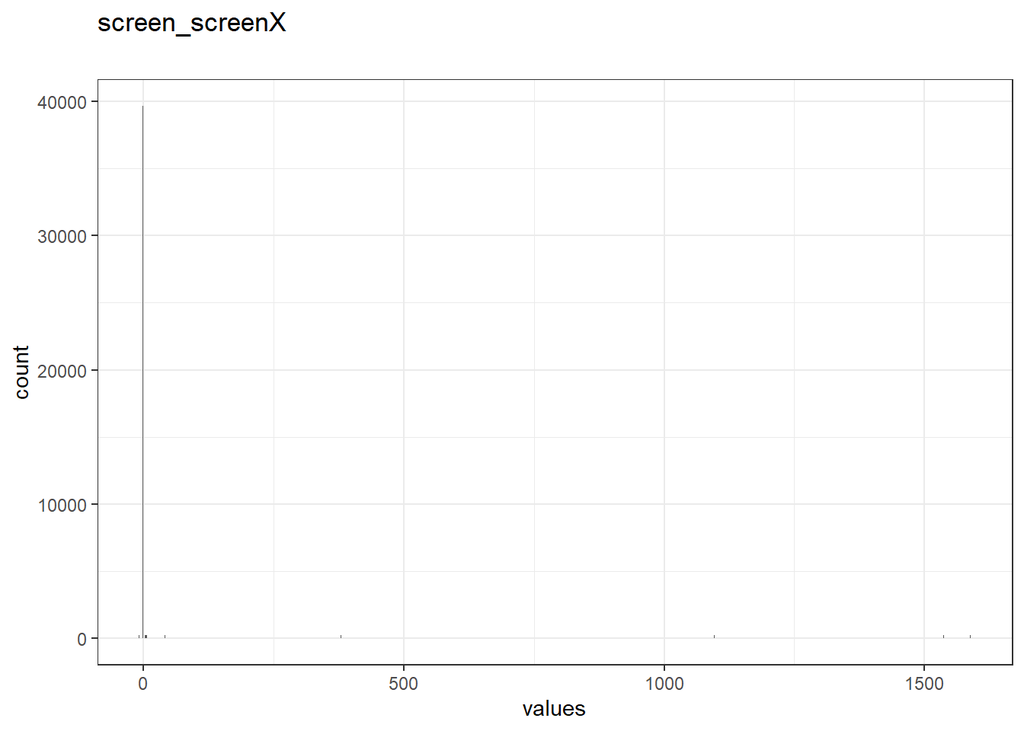

Distribution of values for screen_screenX

0 missing values.

#### Summary statistics

| name | data_type | n_missing | complete_rate | min | median | max | mean | sd | hist | label |
| --- | --- | --- | --- | --- | --- | --- | --- | --- | --- | --- |
| screen_screenX | numeric | 0 | 1 | -7 | 0 | 1588 | 30.99333 | 201.4922 | ▇▁▁▁▁ | NA |

### screen_screenY

#### Distribution

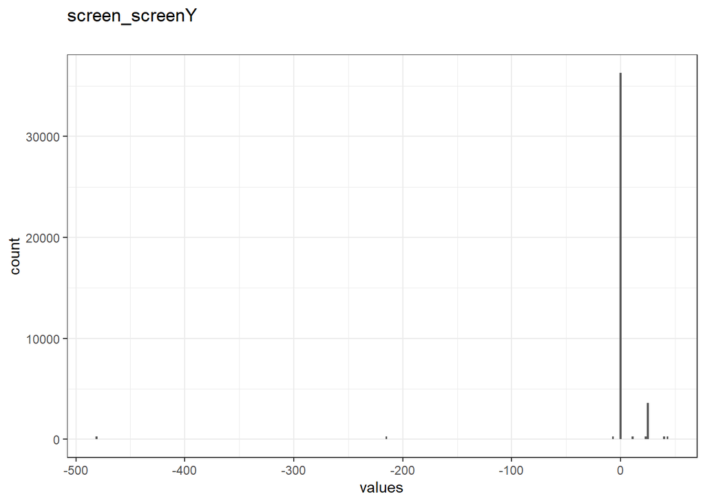

Distribution of values for screen_screenY

0 missing values.

#### Summary statistics

| name | data_type | n_missing | complete_rate | min | median | max | mean | sd | hist | label |
| --- | --- | --- | --- | --- | --- | --- | --- | --- | --- | --- |
| screen_screenY | numeric | 0 | 1 | -481 | 0 | 43 | -1.74 | 43.92507 | ▁▁▁▁▇ | NA |

### screen_width

#### Distribution

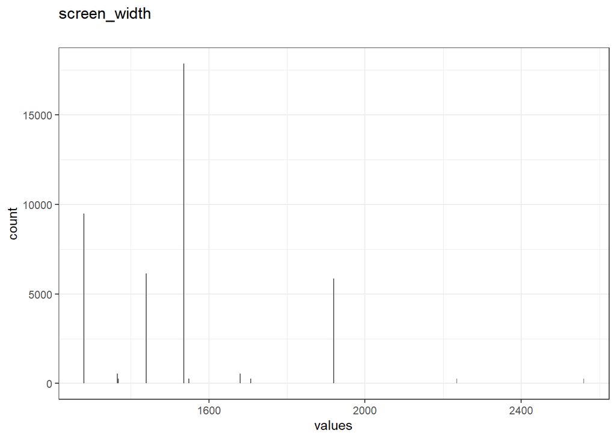

Distribution of values for screen_width

0 missing values.

#### Summary statistics

| name | data_type | n_missing | complete_rate | min | median | max | mean | sd | hist | label |
| --- | --- | --- | --- | --- | --- | --- | --- | --- | --- | --- |
| screen_width | numeric | 0 | 1 | 1280 | 1536 | 2560 | 1528.9 | 219.3057 | ▇▁▂▁▁ | NA |

### system_os

#### Distribution

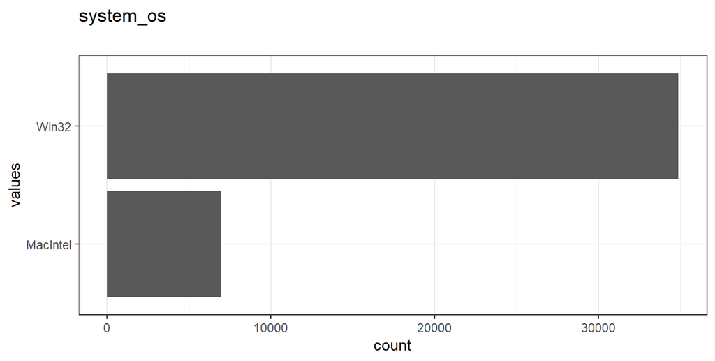

Distribution of values for system_os

0 missing values.

#### Summary statistics

| name | data_type | n_missing | complete_rate | n_unique | empty | min | max | whitespace | label |
| --- | --- | --- | --- | --- | --- | --- | --- | --- | --- |
| system_os | character | 0 | 1 | 2 | 0 | 5 | 8 | 0 | NA |

### Start Time

#### Distribution

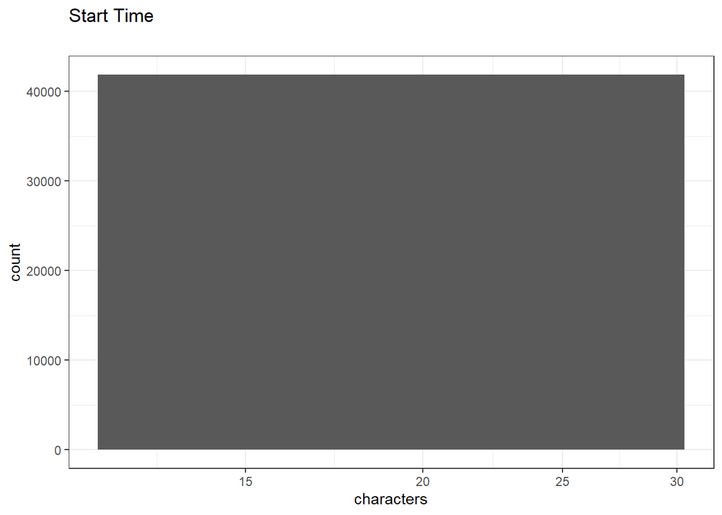

Distribution of values for Start Time

0 missing values.

#### Summary statistics

| name | data_type | n_missing | complete_rate | n_unique | empty | min | max | whitespace | label |
| --- | --- | --- | --- | --- | --- | --- | --- | --- | --- |
| Start Time | character | 0 | 1 | 149 | 0 | 19 | 19 | 0 | NA |

### Last Seen

#### Distribution

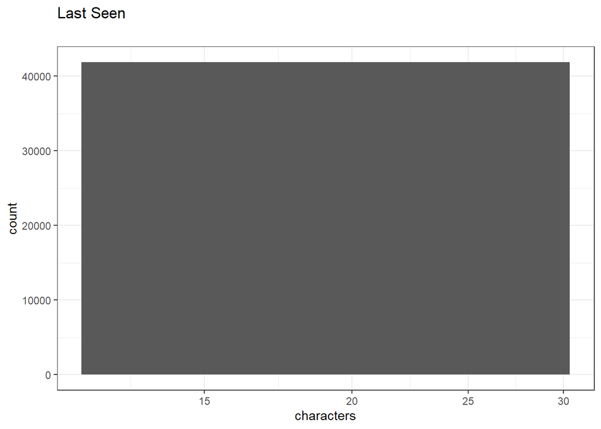

Distribution of values for Last Seen

0 missing values.

#### Summary statistics

| name | data_type | n_missing | complete_rate | n_unique | empty | min | max | whitespace | label |
| --- | --- | --- | --- | --- | --- | --- | --- | --- | --- |
| Last Seen | character | 0 | 1 | 149 | 0 | 19 | 19 | 0 | NA |

### Duration

#### Distribution

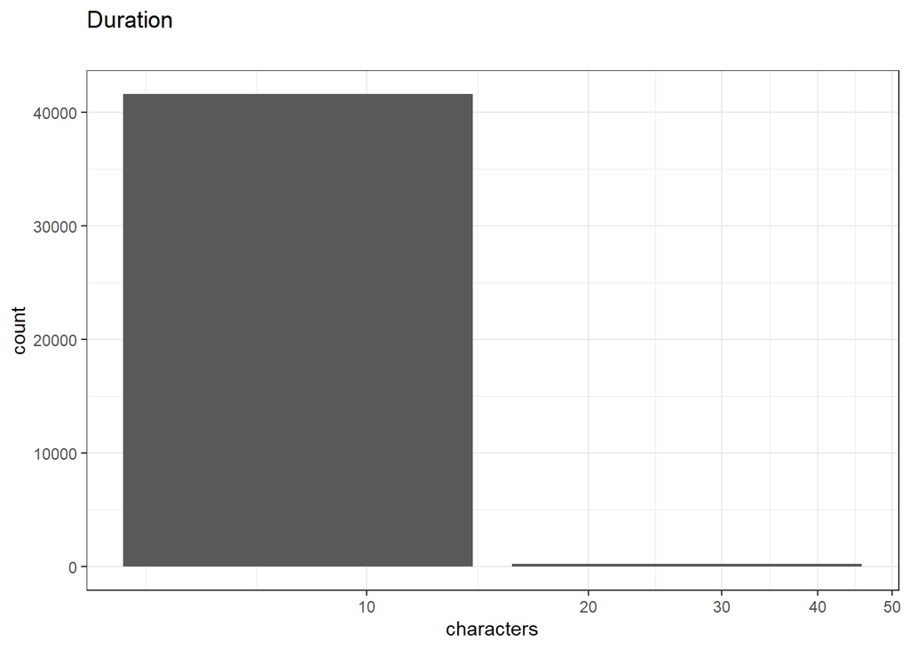

Distribution of values for Duration

0 missing values.

#### Summary statistics

| name | data_type | n_missing | complete_rate | n_unique | empty | min | max | whitespace | label |
| --- | --- | --- | --- | --- | --- | --- | --- | --- | --- |
| Duration | character | 0 | 1 | 145 | 0 | 8 | 27 | 0 | NA |

### Batch

#### Distribution

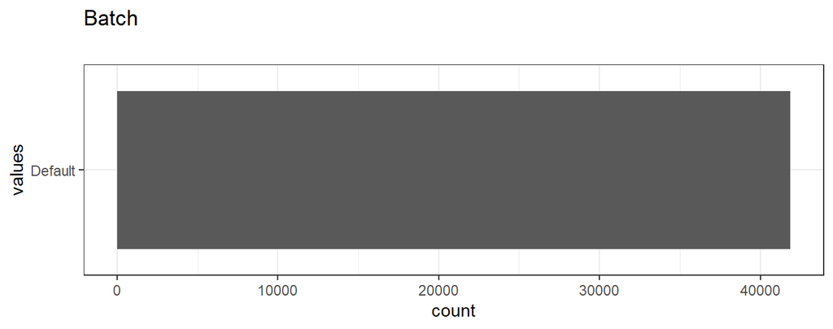

Distribution of values for Batch

0 missing values.

#### Summary statistics

| name | data_type | n_missing | complete_rate | n_unique | empty | min | max | whitespace | label |
| --- | --- | --- | --- | --- | --- | --- | --- | --- | --- |
| Batch | character | 0 | 1 | 1 | 0 | 7 | 7 | 0 | NA |

### Worker ID

#### Distribution

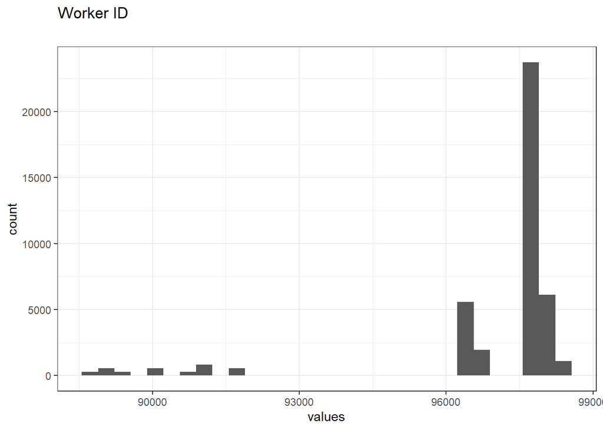

Distribution of values for Worker ID

0 missing values.

#### Summary statistics

| name | data_type | n_missing | complete_rate | min | median | max | mean | sd | hist | label |
| --- | --- | --- | --- | --- | --- | --- | --- | --- | --- | --- |
| Worker ID | numeric | 0 | 1 | 88645 | 97666 | 98318 | 96957.57 | 2044.328 | ▁▁▁▁▇ | NA |

### Worker Type

#### Distribution

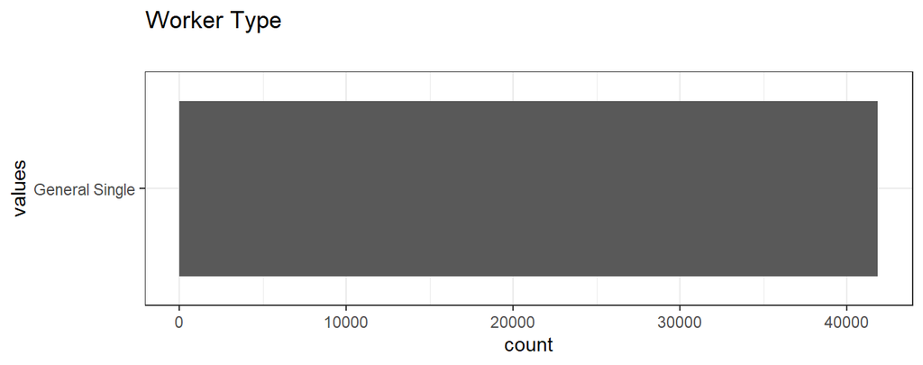

Distribution of values for Worker Type

0 missing values.

#### Summary statistics

| name | data_type | n_missing | complete_rate | n_unique | empty | min | max | whitespace | label |
| --- | --- | --- | --- | --- | --- | --- | --- | --- | --- |
| Worker Type | character | 0 | 1 | 1 | 0 | 14 | 14 | 0 | NA |

### State

#### Distribution

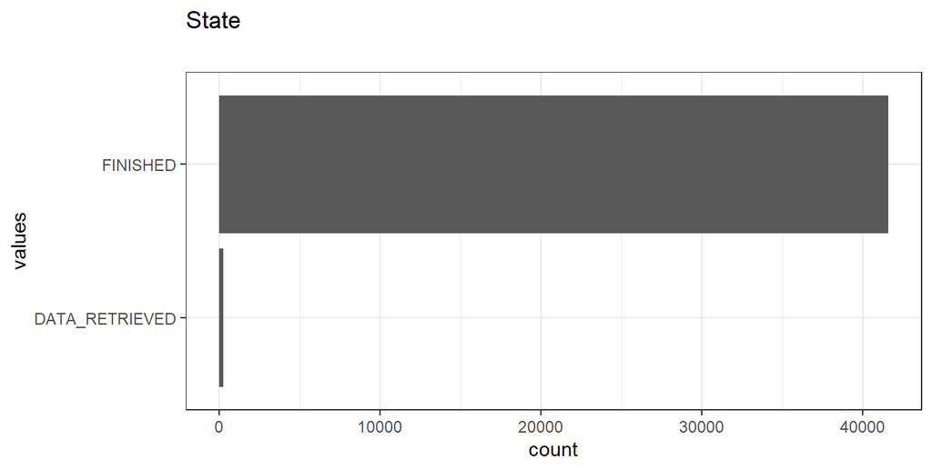

Distribution of values for State

0 missing values.

#### Summary statistics

| name | data_type | n_missing | complete_rate | n_unique | empty | min | max | whitespace | label |
| --- | --- | --- | --- | --- | --- | --- | --- | --- | --- |
| State | character | 0 | 1 | 2 | 0 | 8 | 14 | 0 | NA |

### Message

#### Distribution

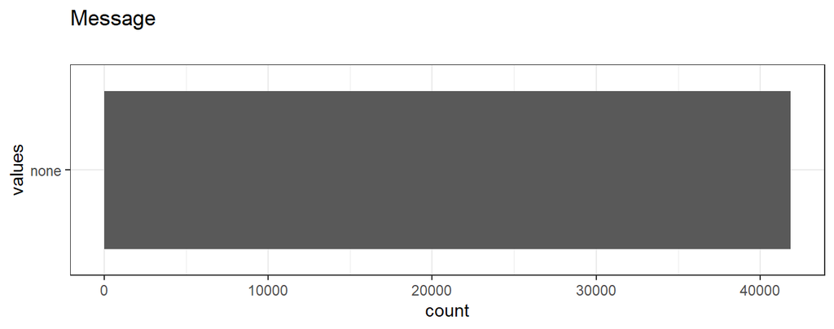

Distribution of values for Message

0 missing values.

#### Summary statistics

| name | data_type | n_missing | complete_rate | n_unique | empty | min | max | whitespace | label |
| --- | --- | --- | --- | --- | --- | --- | --- | --- | --- |
| Message | character | 0 | 1 | 1 | 0 | 4 | 4 | 0 | NA |